# > **Tip**: Welcome to the Investigate a Dataset project! You will find tips in quoted sections like this to help organize your approach to your investigation. Before submitting your project, it will be a good idea to go back through your report and remove these sections to make the presentation of your work as tidy as possible. First things first, you might want to double-click this Markdown cell and change the title so that it reflects your dataset and investigation.

# Project: Investigate Imdb database

- Introduction
- Data Wrangling
- Exploratory Data Analysis
- Conclusions

I have decided to move with Imdb database. I have understood the data based on the datasets present in it. I have taken popularity as the dependent variable and budget, revenue and director as independent variables. I have written my findings here. Questions: 1.Does the revenue of the movie depends upon its popularity? 2.Does the popular movies have more vote_average than the unpopular movies? 3.Top 5 directors based on vote average? 4.Top 5 directors who have produced highest profits in there movies? 5.Top 5 directors who have been described based on revenue and budget? 6.How does the popularity increases based on last 15 years? 7.Top 5 directors based on popularity? 8.How does the popularity differ based on Lead Actors? 9.How does the budget and revenue changes based on last 15 years?

```python
#I have taken all the necessary files for the database and have taken imdb.csv file as my input
import pandas as pd
import numpy as np
import matplotlib.pylab as mp
% matplotlib inline
df=pd.read_csv('imdb.csv')
df.info()
```

```
<class 'pandas.core.frame.DataFrame'>
RangeIndex: 10866 entries, 0 to 10865
Data columns (total 21 columns):
id                      10866 non-null int64
imdb_id                 10856 non-null object
popularity              10866 non-null float64
budget                  10866 non-null int64
revenue                 10866 non-null int64
original_title          10866 non-null object
cast                    10790 non-null object
homepage                2936 non-null object
director                10822 non-null object
tagline                 8042 non-null object
keywords                9373 non-null object
overview                10862 non-null object
runtime                 10866 non-null int64
genres                  10843 non-null object
production_companies    9836 non-null object
release_date            10866 non-null object
vote_count              10866 non-null int64
vote_average            10866 non-null float64
release_year            10866 non-null int64
budget_adj              10866 non-null float64
revenue_adj             10866 non-null float64
dtypes: float64(4), int64(6), object(11)
memory usage: 1.7+ MB
```

--Dropping all the tables which are not needed for the analysis.

```python
# Dropping the files with axis=1 and inplace True which changes your current table
df.drop(['id','imdb_id','homepage','tagline','keywords','overview','runtime','production_companies','release_date','vote_count','budget_adj','revenue_adj'],axis=1,inplace=True)
df.info()
```

```
<class 'pandas.core.frame.DataFrame'>
RangeIndex: 10866 entries, 0 to 10865
Data columns (total 9 columns):
popularity        10866 non-null float64
budget            10866 non-null int64
revenue           10866 non-null int64
original_title    10866 non-null object
cast              10790 non-null object
director          10822 non-null object
genres            10843 non-null object
vote_average      10866 non-null float64
release_year      10866 non-null int64
dtypes: float64(2), int64(3), object(4)
memory usage: 764.1+ KB
```

--Removing All the duplicates from the dataset. Duplicates are not needed for your dataset

```python
# taking the sum of duplicates and dropping it from the current database
sum(df.duplicated())
df.drop_duplicates(inplace=True)
df.info()
```

```
<class 'pandas.core.frame.DataFrame'>
Int64Index: 10865 entries, 0 to 10865
Data columns (total 9 columns):
popularity        10865 non-null float64
budget            10865 non-null int64
revenue           10865 non-null int64
original_title    10865 non-null object
cast              10789 non-null object
director          10821 non-null object
genres            10842 non-null object
vote_average      10865 non-null float64
release_year      10865 non-null int64
dtypes: float64(2), int64(3), object(4)
memory usage: 848.8+ KB
```

--Dropping all the null values to normalize and make the table clean for Analysis

```python
#this will drop all the rows containing the null values from the database. Now the table is clean
df.dropna(inplace=True)
df.info()
```

```
<class 'pandas.core.frame.DataFrame'>
Int64Index: 10731 entries, 0 to 10865
Data columns (total 9 columns):
popularity        10731 non-null float64
budget            10731 non-null int64
revenue           10731 non-null int64
original_title    10731 non-null object
cast              10731 non-null object
director          10731 non-null object
genres            10731 non-null object
vote_average      10731 non-null float64
release_year      10731 non-null int64
dtypes: float64(2), int64(3), object(4)
memory usage: 838.4+ KB
```

--histogram for the current datase. This can help us in understanding the database for numerical values

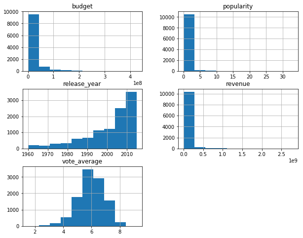

```python
# hist is for analyzing all the numerical values and plotting it
df.hist(figsize=(10,8));
```

--From the above plotting we can understand that the budget and revenue are close to 0 to 0.5 There have been many values which have been initialized with zero. Popularity is varied based on the movie performance release year and vote_average are looking good. With number of movies getting released is directly proportional to years. The vote_average database is looking good

--I am dividing the cast column into number of Lead actors. So that i can perform my calculation with Lead Actors and popularity

```python
"""It was difficult to find this. Took me big time. Well we are using cast column to split the strings based on ' | '
character. Then we are using apply and lambda to create a small funtion that splits the strings and stores it as
panda Series. we are doing this and saving the respective column as lead 1,2,3,4,5."""

foo = lambda x: pd.Series([i for i in (x.split('|'))])
rev = df['cast'].apply(foo)
rev=rev.rename(columns={0:'Lead_1',1:'Lead_2',2:'Lead_3',3:'Lead_4',4:'Lead_5'})
```

-- We are merging the Rev table with df table and dropping the cast column since we dont need it any more.

```python
df1=pd.merge(df,rev,left_index=True, right_index=True)
df1.drop(['cast'],axis=1,inplace=True)
df1.info()
```

```
<class 'pandas.core.frame.DataFrame'>
Int64Index: 10731 entries, 0 to 10865
Data columns (total 13 columns):
popularity        10731 non-null float64
budget            10731 non-null int64
revenue           10731 non-null int64
original_title    10731 non-null object
director          10731 non-null object
genres            10731 non-null object
vote_average      10731 non-null float64
release_year      10731 non-null int64
Lead_1            10731 non-null object
Lead_2            10594 non-null object
Lead_3            10510 non-null object
Lead_4            10404 non-null object
Lead_5            10095 non-null object
dtypes: float64(2), int64(3), object(8)
memory usage: 1.5+ MB
```

```python
Checking for the rows which has missing values . Now i have to take them out.
```

```python
df1[df1.Lead_2.isnull()]
```

|  | popularity | budget | revenue | original_title | director | genres | vote_average | release_year | Lead_1 | Lead_2 | Lead_3 | Lead_4 | Lead_5 |
| --- | --- | --- | --- | --- | --- | --- | --- | --- | --- | --- | --- | --- | --- |
| 334 | 0.357654 | 0 | 0 | Ronaldo | Anthony Wonke | Documentary | 6.5 | 2015 | Cristiano Ronaldo | NaN | NaN | NaN | NaN |
| 341 | 0.348306 | 0 | 16661077 | Monkey Kingdom | Mark Linfield\|Alastair Fothergill | Animation\|Documentary | 6.3 | 2015 | Tina Fey | NaN | NaN | NaN | NaN |
| 494 | 0.129455 | 0 | 0 | Ellis | JR | Drama | 7.2 | 2015 | Robert De Niro | NaN | NaN | NaN | NaN |
| 500 | 0.157172 | 0 | 0 | Amy Schumer: Live at the Apollo | Chris Rock | Comedy | 7.5 | 2015 | Amy Schumer | NaN | NaN | NaN | NaN |
| 545 | 0.109689 | 0 | 0 | Listen to Me Marlon | Stevan Riley | Documentary | 7.0 | 2015 | Marlon Brando | NaN | NaN | NaN | NaN |
| 550 | 0.106091 | 0 | 0 | The Fear of 13 | David Sington | Thriller\|Documentary | 8.2 | 2015 | Sammy Silverwatch | NaN | NaN | NaN | NaN |
| 567 | 0.090045 | 0 | 0 | Chris Tucker: Live | Phil Joanou | Comedy | 6.7 | 2015 | Chris Tucker | NaN | NaN | NaN | NaN |
| 573 | 0.082444 | 0 | 0 | Louis C.K.: Live at The Comedy Store | Louis C.K. | Comedy | 7.7 | 2015 | Louis C.K. | NaN | NaN | NaN | NaN |
| 576 | 0.081820 | 0 | 0 | Aziz Ansari: Live at Madison Square Garden | Aziz Ansari | Comedy | 7.1 | 2015 | Aziz Ansari | NaN | NaN | NaN | NaN |
| 578 | 0.080754 | 0 | 44695 | Requiem for the American Dream | Jared P. Scott\|Peter D. Hutchison\|Kelly Nyks | Documentary | 7.8 | 2015 | Noam Chomsky | NaN | NaN | NaN | NaN |
| 582 | 0.077252 | 0 | 0 | Welcome to Leith | Christopher K. Walker\|Michael Beach Nichols | Thriller\|Crime\|Documentary | 6.7 | 2015 | Craig Cobb | NaN | NaN | NaN | NaN |
| 612 | 0.030819 | 0 | 0 | Dawg Fight | Billy Corben | Documentary | 6.4 | 2015 | Dhafir Harris | NaN | NaN | NaN | NaN |
| 625 | 0.017050 | 0 | 0 | John Mulaney: The Comeback Kid | Rhys Thomas | Comedy | 6.7 | 2015 | John Mulaney | NaN | NaN | NaN | NaN |
| 626 | 0.014647 | 0 | 0 | Meet the Patels | Geeta Patel\|Ravi Patel | Documentary | 6.7 | 2015 | Ravi Patel | NaN | NaN | NaN | NaN |
| 628 | 0.003920 | 0 | 0 | The Emperor's New Clothes | Michael Winterbottom | Documentary | 6.1 | 2015 | Russell Brand | NaN | NaN | NaN | NaN |
| 1168 | 0.163139 | 0 | 0 | Roger Waters: The Wall | Sean Evans\|Roger Waters | Music | 6.9 | 2014 | Roger Waters | NaN | NaN | NaN | NaN |
| 1232 | 0.095131 | 0 | 0 | Road | Michael Hewitt\|Dermot Lavery | Documentary | 7.7 | 2014 | Liam Neeson | NaN | NaN | NaN | NaN |
| 1242 | 0.086750 | 0 | 0 | Jim Jefferies: BARE | Shannon Hartman | Comedy | 7.4 | 2014 | Jim Jefferies | NaN | NaN | NaN | NaN |
| 1243 | 0.083258 | 0 | 0 | Bill Burr: I'm Sorry You Feel That Way | Jay Karas | Comedy | 7.5 | 2014 | Bill Burr | NaN | NaN | NaN | NaN |
| 1284 | 0.096383 | 0 | 0 | Jim Gaffigan: Obsessed | Jay Chapman | Comedy | 7.2 | 2014 | Jim Gaffigan | NaN | NaN | NaN | NaN |
| 1285 | 0.044640 | 0 | 0 | Chelsea Handler Uganda Be Kidding Me Live | James Yukich | Comedy | 6.9 | 2014 | Chelsea Handler | NaN | NaN | NaN | NaN |
| 1295 | 0.097151 | 0 | 0 | Point and Shoot | Marshall Curry | Documentary | 7.2 | 2014 | Matthew Vandyke | NaN | NaN | NaN | NaN |
| 1296 | 0.025920 | 0 | 0 | Maidentrip | Jillian Schlesinger | Adventure\|Documentary | 7.2 | 2014 | Laura Dekker | NaN | NaN | NaN | NaN |
| 1297 | 0.023903 | 0 | 0 | Ballet 422 | Jody Lee Lipes | Documentary\|Music | 6.4 | 2014 | Justin Peck | NaN | NaN | NaN | NaN |
| 1309 | 0.005725 | 0 | 0 | Fat, Sick & Nearly Dead 2 | Kurt Engfehr | Documentary | 6.5 | 2014 | Joe Cross | NaN | NaN | NaN | NaN |
| 1311 | 0.012014 | 0 | 0 | Mitt | Greg Whiteley | Documentary | 6.4 | 2014 | Mitt Romney | NaN | NaN | NaN | NaN |
| 1323 | 0.034538 | 0 | 0 | Stop at Nothing: The Lance Armstrong Story | Alex Holmes | Documentary | 6.7 | 2014 | Reed Albergotti | NaN | NaN | NaN | NaN |
| 1690 | 0.330949 | 0 | 0 | Robin Williams: Weapons of Self Destruction | Marty Callner | Comedy | 6.6 | 2009 | Robin Williams | NaN | NaN | NaN | NaN |
| 1723 | 0.292125 | 0 | 0 | Tales of the Black Freighter | Mike Smith\|Daniel DelPurgatorio | Animation\|Horror\|Action | 6.7 | 2009 | Gerard Butler | NaN | NaN | NaN | NaN |
| 1752 | 0.251166 | 0 | 0 | Under the Sea 3D | Howard Hall | Documentary | 6.8 | 2009 | Jim Carrey | NaN | NaN | NaN | NaN |
| ... | ... | ... | ... | ... | ... | ... | ... | ... | ... | ... | ... | ... | ... |
| 6040 | 0.011798 | 0 | 0 | The Vatican Exorcisms | Joe Marino | Horror\|Documentary\|Mystery | 4.7 | 2013 | Joe Marino | NaN | NaN | NaN | NaN |
| 6051 | 0.112041 | 0 | 0 | Aziz Ansari: Buried Alive | Will Lovelace\|Dylan Southern | Comedy | 7.5 | 2013 | Aziz Ansari | NaN | NaN | NaN | NaN |
| 6074 | 0.002838 | 0 | 0 | Russell Peters: Notorious | David Higby | Comedy | 7.2 | 2013 | Russell Peters | NaN | NaN | NaN | NaN |
| 6401 | 0.330279 | 0 | 0 | Earthlings | Shaun Monson | Documentary | 7.3 | 2005 | Joaquin Phoenix | NaN | NaN | NaN | NaN |
| 6546 | 0.163782 | 0 | 0 | George Carlin: Life Is Worth Losing | Rocco Urbisci | Documentary\|Comedy\|TV Movie | 7.2 | 2005 | George Carlin | NaN | NaN | NaN | NaN |
| 6549 | 0.021811 | 0 | 0 | The Devil and Daniel Johnston | Jeff Feuerzeig | Documentary | 8.3 | 2005 | Daniel Johnston | NaN | NaN | NaN | NaN |
| 6739 | 0.430182 | 0 | 0 | No Time for Nuts | Chris Renaud\|Mike Thurmeier | Adventure\|Animation\|Family | 7.4 | 2006 | Chris Wedge | NaN | NaN | NaN | NaN |
| 6773 | 0.310895 | 0 | 0 | Jeff Dunham: Arguing with Myself | Manny Rodriguez | Comedy | 6.4 | 2006 | Jeff Dunham | NaN | NaN | NaN | NaN |
| 6894 | 0.137913 | 0 | 0 | Planet Earth | Alastair Fothergill | Documentary | 7.6 | 2006 | David Attenborough | NaN | NaN | NaN | NaN |
| 6903 | 0.142518 | 0 | 0 | Zidane, un portrait du 21e siècle | Douglas Gordon\|Philippe Parreno | Documentary\|Foreign | 5.5 | 2006 | Zinedine Zidane | NaN | NaN | NaN | NaN |
| 6936 | 0.067896 | 0 | 0 | Dane Cook: Vicious Circle | Marty Callner\|Dane Cook | Comedy | 7.1 | 2006 | Dane Cook | NaN | NaN | NaN | NaN |
| 7232 | 0.102266 | 0 | 0 | Dave Chappelle: For What it's Worth | Stan Lathan | Comedy | 7.4 | 2004 | Dave Chappelle | NaN | NaN | NaN | NaN |
| 7236 | 0.129785 | 0 | 0 | Chris Rock: Never Scared | Joel Gallen | Comedy | 6.6 | 2004 | Chris Rock | NaN | NaN | NaN | NaN |
| 7256 | 0.001315 | 0 | 0 | Soupçons | Jean-Xavier de Lestrade | Drama\|Documentary | 7.5 | 2004 | Michael Peterson | NaN | NaN | NaN | NaN |
| 7646 | 0.310054 | 0 | 0 | The Land Before Time XIII: The Wisdom of Friends | Jamie Mitchell | Family\|Animation | 6.2 | 2007 | Cody Arens | NaN | NaN | NaN | NaN |
| 7712 | 0.211212 | 0 | 0 | Louis C.K.: Shameless | Steven J. Santos | Comedy | 7.3 | 2007 | Louis C.K. | NaN | NaN | NaN | NaN |
| 7738 | 0.167201 | 0 | 0 | Gabriel Iglesias: Hot and Fluffy | Manny Rodriguez | Comedy | 6.7 | 2007 | Gabriel Iglesias | NaN | NaN | NaN | NaN |
| 7766 | 0.132685 | 0 | 0 | Daniel Tosh: Completely Serious | Manny Rodriguez | Comedy | 6.6 | 2007 | Daniel Tosh | NaN | NaN | NaN | NaN |
| 7862 | 0.147473 | 0 | 0 | The Bugs Bunny/Road Runner Movie | Chuck Jones | Comedy\|Animation\|Family | 6.0 | 1979 | Mel Blanc | NaN | NaN | NaN | NaN |
| 7981 | 0.125596 | 0 | 0 | The Times of Harvey Milk | Rob Epstein | Documentary | 6.3 | 1984 | Harvey Milk | NaN | NaN | NaN | NaN |
| 8370 | 0.035384 | 0 | 0 | Bill Hicks: Relentless | Chris Bould | Comedy | 8.4 | 1992 | Bill Hicks | NaN | NaN | NaN | NaN |
| 8374 | 0.006863 | 0 | 0 | Gayniggers from Outer Space | Morten Lindberg | Comedy\|Science Fiction | 4.0 | 1992 | Gbatokai Dakinah | NaN | NaN | NaN | NaN |
| 8706 | 0.811101 | 0 | 0 | For the Birds | Ralph Eggleston | Animation\|Comedy\|Family | 7.7 | 2000 | Ralph Eggleston | NaN | NaN | NaN | NaN |
| 8839 | 0.157001 | 0 | 0 | Dave Chappelle: Killin' Them Softly | Stan Lathan | Comedy | 8.5 | 2000 | Dave Chappelle | NaN | NaN | NaN | NaN |
| 8923 | 0.391453 | 60000 | 0 | Vincent | Tim Burton | Animation\|Drama\|Fantasy | 7.9 | 1982 | Vincent Price | NaN | NaN | NaN | NaN |
| 9757 | 0.005265 | 0 | 0 | The Alphabet | David Lynch | Animation | 5.9 | 1968 | Peggy Lynch | NaN | NaN | NaN | NaN |
| 9793 | 0.172363 | 0 | 0 | Animals Are Beautiful People | Jamie Uys | Comedy\|Documentary | 7.4 | 1974 | Paddy O'Byrne | NaN | NaN | NaN | NaN |
| 10012 | 0.519773 | 0 | 0 | A Grand Day Out | Nick Park | Adventure\|Animation\|Comedy\|Science Fiction\|Family | 7.3 | 1990 | Peter Sallis | NaN | NaN | NaN | NaN |
| 10238 | 0.996113 | 0 | 0 | The Wrong Trousers | Nick Park | Animation\|Comedy\|Family | 7.4 | 1993 | Peter Sallis | NaN | NaN | NaN | NaN |
| 10397 | 0.012941 | 0 | 0 | Bill Hicks: Revelations | Chris Bould | Comedy | 7.8 | 1993 | Bill Hicks | NaN | NaN | NaN | NaN |

137 rows × 13 columns